# Finding Donors for *CharityML*

CharityML is a fictitious charity organization located in the heart of Silicon Valley that was established to provide financial support for people eager to learn machine learning. After nearly 32,000 letters were sent to people in the community, CharityML determined that every donation they received came from someone that was making more than \$50,000 annually. To expand their potential donor base, CharityML has decided to send letters to residents of California, but to only those most likely to donate to the charity. We will want to create a model that can correctly identify the individuals which should be asked for donations in our to maximize donations and minimize wasted letters.

The dataset for this project originates from the [UCI Machine Learning Repository](https://archive.ics.uci.edu/ml/datasets/Census+Income). The data we investigate here consists of small changes to the original dataset, such as removing the `'fnlwgt'` feature and records with missing or ill-formatted entries.

- **age**: continuous.
- **workclass**: Private, Self-emp-not-inc, Self-emp-inc, Federal-gov, Local-gov, State-gov, Without-pay, Never-worked.
- **education**: Bachelors, Some-college, 11th, HS-grad, Prof-school, Assoc-acdm, Assoc-voc, 9th, 7th-8th, 12th, Masters, 1st-4th, 10th, Doctorate, 5th-6th, Preschool.
- **education-num**: continuous.
- **marital-status**: Married-civ-spouse, Divorced, Never-married, Separated, Widowed, Married-spouse-absent, Married-AF-spouse.
- **occupation**: Tech-support, Craft-repair, Other-service, Sales, Exec-managerial, Prof-specialty, Handlers-cleaners, Machine-op-inspct, Adm-clerical, Farming-fishing, Transport-moving, Priv-house-serv, Protective-serv, Armed-Forces.
- **relationship**: Wife, Own-child, Husband, Not-in-family, Other-relative, Unmarried.
- **race**: Black, White, Asian-Pac-Islander, Amer-Indian-Eskimo, Other.
- **sex**: Female, Male.
- **capital-gain**: continuous.
- **capital-loss**: continuous.
- **hours-per-week**: continuous.
- **native-country**: United-States, Cambodia, England, Puerto-Rico, Canada, Germany, Outlying-US(Guam-USVI-etc), India, Japan, Greece, South, China, Cuba, Iran, Honduras, Philippines, Italy, Poland, Jamaica, Vietnam, Mexico, Portugal, Ireland, France, Dominican-Republic, Laos, Ecuador, Taiwan, Haiti, Columbia, Hungary, Guatemala, Nicaragua, Scotland, Thailand, Yugoslavia, El-Salvador, Trinadad&Tobago, Peru, Hong, Holand-Netherlands.

### Project Outline:

#### Data Exploration:

- Plot histograms of numeric columns (distribution analysis).
- Explore any stand out findings from the numeric columns in more detail.
- Create a heatmap to see the correlation between label and features.
- Calculate general statistics of the data.

#### Data Preprocessing:

- Transform any highly skewed data that has been found.
- Normalize our numerical features to a scale [0,1].
- Encode our categorical features and labels to numeric format.
- Split our data into training and testing sets (80/20).

#### Initial Modeling:

- Create a Naive model (baseline prediction).
- Train 3 initial models.
- Choose best model to tune based on evaluation metrics (F-score).

#### Hyperparameter Tuning:

- Use Grid Search to find the optimal hyperparamter values based on an F-score with $\beta = 0.5$
- Plot an ROC curve and check AUC to see how our model is performing.

#### Feature Importance:

- Find the 5 most important features used in the model training.
- Use the subset of important features to train a simpler model and see if we see any improvements.

## Data Exploration

### Load in data

```python
import numpy as np
import pandas as pd
from time import time
import visuals as vs # external tools used for visualization
import matplotlib.pyplot as plt
%matplotlib inline

# Load the Census dataset
data = pd.read_csv("census.csv")

data.head()
```

|  | age | workclass | education_level | education-num | marital-status | occupation | relationship | race | sex | capital-gain | capital-loss | hours-per-week | native-country | income |
| --- | --- | --- | --- | --- | --- | --- | --- | --- | --- | --- | --- | --- | --- | --- |
| 0 | 39 | State-gov | Bachelors | 13.0 | Never-married | Adm-clerical | Not-in-family | White | Male | 2174.0 | 0.0 | 40.0 | United-States | <=50K |
| 1 | 50 | Self-emp-not-inc | Bachelors | 13.0 | Married-civ-spouse | Exec-managerial | Husband | White | Male | 0.0 | 0.0 | 13.0 | United-States | <=50K |
| 2 | 38 | Private | HS-grad | 9.0 | Divorced | Handlers-cleaners | Not-in-family | White | Male | 0.0 | 0.0 | 40.0 | United-States | <=50K |
| 3 | 53 | Private | 11th | 7.0 | Married-civ-spouse | Handlers-cleaners | Husband | Black | Male | 0.0 | 0.0 | 40.0 | United-States | <=50K |
| 4 | 28 | Private | Bachelors | 13.0 | Married-civ-spouse | Prof-specialty | Wife | Black | Female | 0.0 | 0.0 | 40.0 | Cuba | <=50K |

### Plot numeric features

Plot a subset of the numeric features to see the distributions and where the values fall.

- It looks like `Age` is right skewed, with the majority of the data coming from under approx. 45 years old.
- `Education Number` seems to be mostly concentrated in the values 9, 10, and 13.
- `Capital Gain` seems to be highly concentrated below 20,000 with outliers in the 90,000 range.
- `Capital Loss` seems to be focues mainly around, with some expections in the 1500 to 2200 range.
- `Hours Per Week` has a similar distribution to the normal distribution, but with a large spike in the 35-40 range (meaning most of the data is coming from full-time workers).

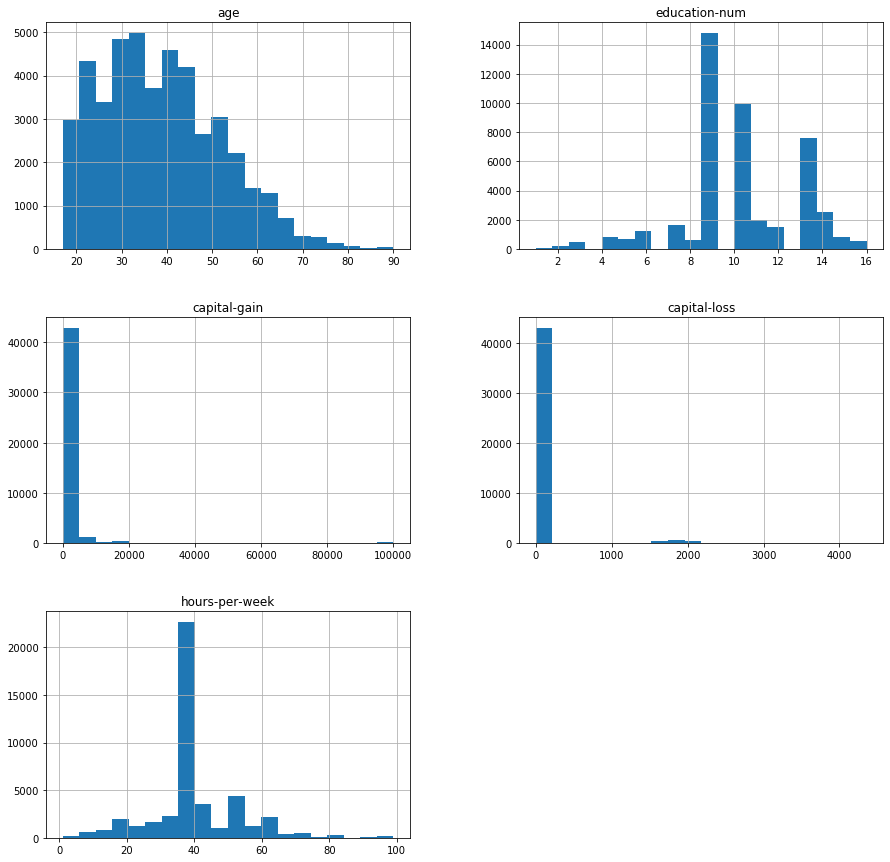

```python
plot_cols = ['age', 'education-num', 'capital-gain', 'capital-loss', 'hours-per-week']

data[plot_cols].hist(bins=20, figsize=(15,15))
plt.show();
```

```python
zero_gain = data['capital-gain'].value_counts()[0]
zero_gain_prop = round((zero_gain / len(data))*100, 2)
zero_loss = data['capital-loss'].value_counts()[0]
zero_loss_prop = round((zero_loss / len(data))*100, 2)
print('{}% of the capital gain feature is equal to 0.'.format(zero_gain_prop))
print('{}% of the capital loss feature is equal to 0.'.format(zero_loss_prop))
```

```
91.62% of the capital gain feature is equal to 0.
95.27% of the capital loss feature is equal to 0.
```

We can see that `capital-gain` is highly skewed with around 91.6% of the observations having a value of 0. We can see that `capital-loss` is highly skewed with around 95.3% of the observations having a value of 0. This means a majority of the observations do not have any profit or loss from sales of assets. This could be due to the class imbalance, with a majority of the observations having an income below 50K and possibly not having the income to purchase assets for investment/sale.

### Create a Heatmap

Create a heatmap of the correlation matrix for our numerical features. Create a copy of the data and modify the income to be numeric in order to see the correlation between income and other numeric features.

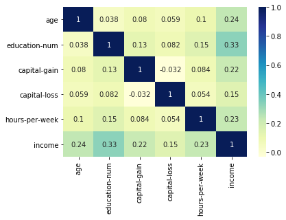

```python
import seaborn as sns

heatmap_df = data.copy()
heatmap_df['income'] = heatmap_df['income'].map({'<=50K': 0, '>50K':1})

sns.heatmap(heatmap_df.corr(), annot=True, cmap='YlGnBu')
```

### Calculate Statistics

We want to find a deeper understanding of our numeric data than just the graphs. We can do so with:

- Calculating summary statistics.
- Looking further into any outliers in our data (mainly capital gain as seen in graph above).
- Finding the total number of records, how many observations of each class we have, and sample proportions.

```python
data.describe()
```

|  | age | education-num | capital-gain | capital-loss | hours-per-week |
| --- | --- | --- | --- | --- | --- |
| count | 45222.000000 | 45222.000000 | 45222.000000 | 45222.000000 | 45222.000000 |
| mean | 38.547941 | 10.118460 | 1101.430344 | 88.595418 | 40.938017 |
| std | 13.217870 | 2.552881 | 7506.430084 | 404.956092 | 12.007508 |
| min | 17.000000 | 1.000000 | 0.000000 | 0.000000 | 1.000000 |
| 25% | 28.000000 | 9.000000 | 0.000000 | 0.000000 | 40.000000 |
| 50% | 37.000000 | 10.000000 | 0.000000 | 0.000000 | 40.000000 |
| 75% | 47.000000 | 13.000000 | 0.000000 | 0.000000 | 45.000000 |
| max | 90.000000 | 16.000000 | 99999.000000 | 4356.000000 | 99.000000 |

```python
# Explore Capital Gain Column

n_observations = len(data)
some_gain = len(data[data['capital-gain'] > 0]) # all observations with some kind of capital gain
no_gain = len(data[data['capital-gain'] == 0]) # all observations with no capital gain
over_20_gain = len(data[data['capital-gain'] > 20000]) # all observations over where the graph picked up on
over_80_gain = len(data[data['capital-gain'] > 80000]) # extreme outliers

print('Observations with capital gain over $0: {}'.format(some_gain))
print('Observations with capital gain equal to $0: {}'.format(no_gain))
print('Observations with capital gain over $20,000: {}'.format(over_20_gain))
print('{}% of the observations are above $20,000'.format((over_20_gain/n_observations)*100))
print('Observations with capital gain over $80,000: {}'.format(over_80_gain))
print('{}% of the observations are above $80,000'.format((over_80_gain/n_observations)*100))
```

```
Observations with capital gain over $0: 3790
Observations with capital gain equal to $0: 41432
Observations with capital gain over $20,000: 355
0.7850161425854673% of the observations are above $20,000
Observations with capital gain over $80,000: 229
0.506390694794569% of the observations are above $80,000
```

**Note:** We can see only 0.78% of our observations have a capital gain value over 20,000 and only 0.506% of our observations have a capital gain over 80,000. Possbily removing these observations can help our model if it seems to need it.

```python
n_records = len(data)

n_greater_50k = len(data[data['income'] == '>50K']) # Number of records where income is more than $50,000

n_at_most_50k = len(data[data['income'] == '<=50K']) # Number of records where income is at most $50,000

greater_percent = round((n_greater_50k / n_records)*100, 2) # Percentage of records where income is more than $50,000

at_most_percent = 100-greater_percent # Percentage of records where income is at most $50,000

# Print the results
print("Total number of records: {}".format(n_records))
print("Individuals making more than $50,000: {}".format(n_greater_50k))
print("Individuals making at most $50,000: {}".format(n_at_most_50k))
print("Percentage of individuals making more than $50,000: {}%".format(greater_percent))
print("Percentage of individuals making at most $50,000: {}%".format(at_most_percent))
```

```
Total number of records: 45222
Individuals making more than $50,000: 11208
Individuals making at most $50,000: 34014
Percentage of individuals making more than $50,000: 24.78%
Percentage of individuals making at most $50,000: 75.22%
```

**Note:** We can see a slight class imbalance, so we want to keep this in mind when training (possibly use a Random Forest Classifier to automatically handle the imbalance for us).

## Data Preprocessing

### Transforming Skewed Data

Both `capital gain` and `capital loss` were highly skewed and had a majority of their data equal to 0. We want to apply a logarithmic transformation so that the small and large values do not effect model performance.

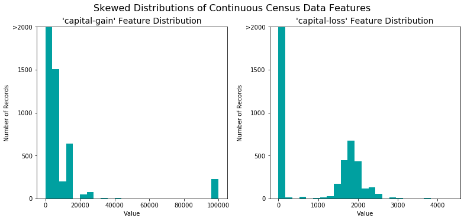

```python
income_raw = data['income'] # features
features_raw = data.drop('income', axis = 1) # labels

vs.distribution(data) # Visualize skewed continuous features of original data
```

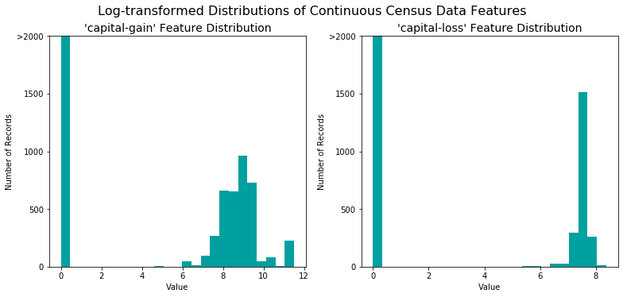

```python
# Log-transform the skewed features
skewed = ['capital-gain', 'capital-loss']
features_log_transformed = pd.DataFrame(data = features_raw)
features_log_transformed[skewed] = features_raw[skewed].apply(lambda x: np.log(x + 1))

vs.distribution(features_log_transformed, transformed = True) # Visualize the new log distributions
```

### Normalizing Numerical Features

We want to normalize all of our numeric features so that they are each treated equally when training our model. We do not want one feature to have more influence than others because of its numerical value in proportion to another. We will change the range of values these numerical features can take on to a range [0,1].

```python
from sklearn.preprocessing import MinMaxScaler

# Initialize a scaler, then apply it to the features
scaler = MinMaxScaler()
numerical = ['age', 'education-num', 'capital-gain', 'capital-loss', 'hours-per-week']

features_log_minmax_transform = pd.DataFrame(data = features_log_transformed)
features_log_minmax_transform[numerical] = scaler.fit_transform(features_log_transformed[numerical])

features_log_minmax_transform.head()
```

|  | age | workclass | education_level | education-num | marital-status | occupation | relationship | race | sex | capital-gain | capital-loss | hours-per-week | native-country |
| --- | --- | --- | --- | --- | --- | --- | --- | --- | --- | --- | --- | --- | --- |
| 0 | 0.301370 | State-gov | Bachelors | 0.800000 | Never-married | Adm-clerical | Not-in-family | White | Male | 0.667492 | 0.0 | 0.397959 | United-States |
| 1 | 0.452055 | Self-emp-not-inc | Bachelors | 0.800000 | Married-civ-spouse | Exec-managerial | Husband | White | Male | 0.000000 | 0.0 | 0.122449 | United-States |
| 2 | 0.287671 | Private | HS-grad | 0.533333 | Divorced | Handlers-cleaners | Not-in-family | White | Male | 0.000000 | 0.0 | 0.397959 | United-States |
| 3 | 0.493151 | Private | 11th | 0.400000 | Married-civ-spouse | Handlers-cleaners | Husband | Black | Male | 0.000000 | 0.0 | 0.397959 | United-States |
| 4 | 0.150685 | Private | Bachelors | 0.800000 | Married-civ-spouse | Prof-specialty | Wife | Black | Female | 0.000000 | 0.0 | 0.397959 | Cuba |

### One-Hot-Encoding of Categorical Data

We still need to transform our categorical data into a format that can be used by our algorithm, typically numeric format. We can do this by using one-hot-encoding to create dummy variables for each possibly category of each non-numeric feature. The below table shows what occurs during this process:

|  | someFeature |  | someFeature_A | someFeature_B | someFeature_C |
| --- | --- | --- | --- | --- | --- |
| 0 | B |  | 0 | 1 | 0 |
| 1 | C | ----> one-hot encode ----> | 0 | 0 | 1 |
| 2 | A |  | 1 | 0 | 0 |

```python
# One-hot encode the 'features_log_minmax_transform' data
features_final = pd.get_dummies(features_log_minmax_transform)

income = income_raw.map({'<=50K': 0, '>50K':1}) # Encode the labels to numerical values

encoded = list(features_final.columns)
print("{} total features after one-hot encoding.".format(len(encoded))) # Print the number of features after encoding
```

```
103 total features after one-hot encoding.
```

### Shuffle and Split Data

Now that our data is in correct format, we want to split this into training and test sets using an 80/20 split, respectively.

```python
from sklearn.model_selection import train_test_split

# Split the features and corresponding labels into training and testing sets
X_train, X_test, y_train, y_test = train_test_split(features_final,
                                                    income,
                                                    test_size = 0.2,
                                                    random_state = 0)

print("Training set has {} samples.".format(X_train.shape[0]))
print("Testing set has {} samples.".format(X_test.shape[0]))
```

```
Training set has 36177 samples.
Testing set has 9045 samples.
```

## Initial Modeling

*CharityML*, equipped with their research, knows individuals that make more than \$50,000 are most likely to donate to their charity. Because of this, *CharityML* is particularly interested in predicting who makes more than \$50,000 accurately. It would seem that using **accuracy** as a metric for evaluating a particular model's performace would be appropriate. Additionally, identifying someone that *does not* make more than \$50,000 as someone who does would be detrimental to *CharityML*, since they are looking to find individuals willing to donate. Therefore, a model's ability to precisely predict those that make more than \$50,000 is *more important* than the model's ability to **recall** those individuals. We can use **F-beta score** as a metric that considers both precision and recall. In particular, when $\beta = 0.5$, more emphasis is placed on precision. This is called the **F$_{0.5}$ score** (or F-score for simplicity).

Looking at the distribution of classes (those who make at most 50K, and those who make more), it's clear most individuals do not make more than \$50,000. This can greatly affect **accuracy**, since we could simply say "this person does not make more than \$50,000" and generally be right, without ever looking at the data.

### Naive Model (No training)

The purpose of this is to see a base model that has no training and see what metrics it can produce. This will help us gauge how well our trained models should be performing at the bare minimum. We will assume that our naive model guess that every observations made over 50K. We will evaluate this with accuracy and F-score since these will be our metrics in our model.

```python
accuracy = np.sum(income)/len(income)
recall = np.sum(income)/np.sum(income)
precision = np.sum(income)/len(income)

fscore = (1+0.5**2)*((precision*recall)/(precision*0.5**2 + recall)) # Calculate F-score with beta = 0.5

print("Naive Predictor: [Accuracy score: {:.4f}, F-score: {:.4f}]".format(accuracy, fscore))
```

```
Naive Predictor: [Accuracy score: 0.2478, F-score: 0.2917]
```

### Training and Predicting Pipeline

Create a pipeline so we can train and evaluate multiple models without repeating code.

```python
from sklearn.metrics import accuracy_score, fbeta_score

def train_predict(learner, sample_size, X_train, y_train, X_test, y_test):
    '''
    inputs:
       - learner: the learning algorithm to be trained and predicted on
       - sample_size: the size of samples (number) to be drawn from training set
       - X_train: features training set
       - y_train: income training set
       - X_test: features testing set
       - y_test: income testing set
    '''

    results = {}

    # Fit the learner to the training data for size specified by sample_size
    start = time() # Get start time
    learner = learner.fit(X_train[:sample_size], y_train[:sample_size])
    end = time() # Get end time
    results['train_time'] = end - start # Calculate the training time

    start = time() # Get start time
    predictions_test = learner.predict(X_test) # Make predictions on test data
    predictions_train = learner.predict(X_train[:300]) # make predictions of first 300 samples of training data
    end = time() # Get end time
    results['pred_time'] = end - start # Calculate the total prediction time

    results['acc_train'] = accuracy_score(y_train[:300], predictions_train)  # Training Accuracy for first 300 samples

    results['acc_test'] = accuracy_score(y_test, predictions_test) # Testing Accuracy

    # Compute F-score on the the first 300 training samples using beta=0.5
    results['f_train'] = fbeta_score(y_train[:300], predictions_train, beta=0.5)

    # Compute F-score on the test set using beta=0.5
    results['f_test'] = fbeta_score(y_test, predictions_test, beta=0.5)

    print("{} trained on {} samples.".format(learner.__class__.__name__, sample_size)) # Success

    return results
```

### Initial Model Evaluation

We will use 3 algorithms to train on the census data, then chose which performed best based on our metrics. We will then continue to fine-tune that model. The three models we will use are:

**1. Logistic Regression**:

- Advantage: Logistic regression is extremely fast at training and predicting, meaning that our computational cost will be low with this model.
- Disadvantage: It uses linear bounds, so it makes the assumption that our features are linearly seperable. If our data is mixed together, the model will not perform as well as others.
- Reasoning: We know we want to minimize the computational cost for our problem, so this model is a good choice.

**2. Random Forest Classifier**:

- Advantage: It reduces overfitting by using bagging to create multiple decision trees to find the boundary lines. It can handle missing data automatically (which we do not have any of). It also can handle large datasets with a large number of input features.
- Disadvantage: It is a complex algorithm and takes longer for training, which means an increase in computational cost.
- Reasoning: The model is a good candidate because we know we have a class imbalance (around 3x more <=50K than >50K) and Random Forests can balance errors when there are class imbalances.

**3. AdaBoost Classifier**:

- Advantage: The algorithm uses multiple weak learns to create a single strong learner. It is also relatively quick in training and predicting.
- Disadvantage: AdaBoost is sensitive to outliers, but since we scaled all of our data we won't have this issue.
- Reasoning: We want a computationally low costing algorithm, so this is a good fit.

```
LogisticRegression trained on 361 samples.
LogisticRegression trained on 3617 samples.
```

```
LogisticRegression trained on 36177 samples.
RandomForestClassifier trained on 361 samples.
RandomForestClassifier trained on 3617 samples.
RandomForestClassifier trained on 36177 samples.
AdaBoostClassifier trained on 361 samples.
AdaBoostClassifier trained on 3617 samples.
AdaBoostClassifier trained on 36177 samples.
```

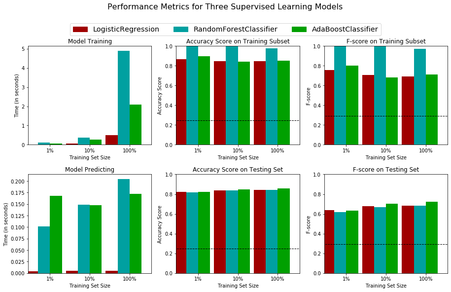

```python
from sklearn.linear_model import LogisticRegression
from sklearn.ensemble import RandomForestClassifier, AdaBoostClassifier

# Initialize the three models
clf_A = LogisticRegression(random_state=42)
clf_B = RandomForestClassifier(random_state=42)
clf_C = AdaBoostClassifier(random_state=42)

# Calculate the number of samples for 1%, 10%, and 100% of the training data
samples_100 = len(y_train)
samples_10 = int(len(y_train)*.1)
samples_1 = int(len(y_train)*.01)

# Collect results on the learners
results = {}
for clf in [clf_A, clf_B, clf_C]:
    clf_name = clf.__class__.__name__
    results[clf_name] = {}
    for i, samples in enumerate([samples_1, samples_10, samples_100]):
        results[clf_name][i] = \
        train_predict(clf, samples, X_train, y_train, X_test, y_test)

vs.evaluate(results, accuracy, fscore) # Run metrics visualization for the three supervised learning models chosen
```

**Best Model:**

I believe that the AdaBoost algorithm will be the best model for the task of identifying individuals that make more than $50,000. Looking at our graphs above, AdaBoost had the highest F-score and testing accuracy of the three initial models. Although it was not the most efficient in terms of the computational cost, its training time was on the mid-lower range and it did have fairly consistent prediction time. We could use Logistic Regression if we wanted to minimize the computational cost, but this also assumes that our data features are linearly seperable (which we do not know for sure). The Random Forests model also had the highest computational cost and seemed to be overfitting, so this model does not seem well suited for our problem given its initial performance.

The AdaBoost algorithm will give us mid-range computational costs and the highest accuracy/F1 score of the models, so we will choose this one. Given that we normalized our data, the algorithm will not have an issue with strong influence from outliers. I believe with tuning, we can correctly classify a majority of the data and increase this algorithms accuracy and F1 scores.

**Layman's Terms:**

The idea behind AdaBoost can be explained by an example. Say you're preparing for an exam and you ask your friends for help, but each one of your friends is only strong in one subject, and there are multiple subjects on the test. Each one of your friends helps you study, but you take more advice from the subject that they are strongest in and less advice from the other subjects they don't know as well. Putting all this information together from your friends, you can then have a strong understanding of all the subjects on the test. Since you now have a strong understanding of each subject, then when it comes time to take the test (similar to predicting for our model), you'll be able to answer questions that you haven't seen before on the material you study (or trained on in terms of our model).

## Hyperparameter Tuning

Now that we have chosen the model best suited to our problem, we will use Grid Search to find the optimal parameters for our model. We will evaluate this based on an F-score with beta=0.5, as well as taking into account accuracy score.

```python
from sklearn.model_selection import GridSearchCV
from sklearn.metrics import make_scorer

clf = AdaBoostClassifier(random_state=42) # Initialize the classifier

# Create parameter dictionary for tuning
parameters = {'n_estimators': np.arange(400, 1001, 100),
              'learning_rate': [.01, .1, 1, 3]}

scorer = make_scorer(fbeta_score, beta=0.5) # Make an fbeta_score scoring object

# Perform grid search on the classifier using 'scorer' as the scoring method
grid_obj = GridSearchCV(clf, parameters, scoring=scorer, verbose=1)

grid_fit = grid_obj.fit(X_train, y_train) # Fit the grid search object to the training data and find the optimal parameters

best_clf = grid_fit.best_estimator_ # Get the estimator

# Make predictions using the unoptimized and optimized model
predictions = (clf.fit(X_train, y_train)).predict(X_test)
best_predictions = best_clf.predict(X_test)

# Report the before-and-afterscores
print("Unoptimized model\n------")
print("Accuracy score on testing data: {:.4f}".format(accuracy_score(y_test, predictions)))
print("F-score on testing data: {:.4f}".format(fbeta_score(y_test, predictions, beta = 0.5)))
print("\nOptimized Model\n------")
print("Final accuracy score on the testing data: {:.4f}".format(accuracy_score(y_test, best_predictions)))
print("Final F-score on the testing data: {:.4f}".format(fbeta_score(y_test, best_predictions, beta = 0.5)))
```

```
Fitting 5 folds for each of 28 candidates, totalling 140 fits
```

```
[Parallel(n_jobs=1)]: Using backend SequentialBackend with 1 concurrent workers.
[Parallel(n_jobs=1)]: Done 140 out of 140 | elapsed: 50.4min finished
```

```
Unoptimized model
------
Accuracy score on testing data: 0.8576
F-score on testing data: 0.7246

Optimized Model
------
Final accuracy score on the testing data: 0.8676
Final F-score on the testing data: 0.7448
```

The optimized model had an accuracy score of 86.76% and an F-score of 74.48%. These were an improvement over the unoptimized model, with accuracy score increasing by approximately 1% and F-score increasing by approximately 2%. From the naive predictor benchmarks, these optimized model scores were more than twice as accurate for each metric. With only a slight increase from unoptimized to optimized, this leads me to think that with different hyperparameter values and more tuning, we would be able to increase our model even more.

### Plot an ROC curve

```python
from sklearn.metrics import roc_curve, auc, roc_auc_score

def build_roc_auc(model, X_train, X_test, y_train, y_test):
    '''
    INPUT:
    model - an sklearn instantiated model
    X_train - the training data
    y_train - the training response values (must be categorical)
    X_test - the test data
    y_test - the test response values (must be categorical)
    OUTPUT:
    auc - returns auc as a float
    prints the roc curve
    '''
    y_preds = model.fit(X_train, y_train).predict_proba(X_test)
    # Compute ROC curve and ROC area for each class
    fpr = dict()
    tpr = dict()
    roc_auc = dict()
    for i in range(len(y_test)):
        fpr[i], tpr[i], _ = roc_curve(y_test, y_preds[:, 1])
        roc_auc[i] = auc(fpr[i], tpr[i])

    # Compute micro-average ROC curve and ROC area
    fpr["micro"], tpr["micro"], _ = roc_curve(y_test.ravel(), y_preds[:, 1].ravel())
    roc_auc["micro"] = auc(fpr["micro"], tpr["micro"])

    plt.plot(fpr[2], tpr[2], color='darkorange', lw=2,
             label='ROC curve (area = %0.2f)' % roc_auc[2])
    plt.plot([0, 1], [0, 1], color='navy', lw=2, linestyle='--')
    plt.xlim([0.0, 1.0])
    plt.ylim([0.0, 1.05])
    plt.xlabel('False Positive Rate')
    plt.ylabel('True Positive Rate')
    plt.title('Receiver operating characteristic example')
    plt.show();

    return roc_auc_score(y_test, np.round(y_preds[:, 1]))
```

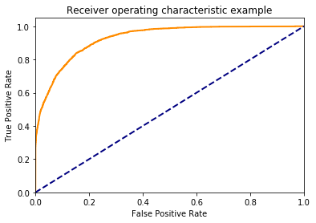

```
0.7913444325098461
```

```python
build_roc_auc(best_clf, X_train, X_test, y_train, y_test)
```

The ideal value for the AUC is 1, and our model acheived a score of 0.79. Our model is doing a decent job at differentiating the classes from one another, but there is still room for improvement. I think with more training and tuning, we could increase the score above.

## Feature Importance

We now want to determine which features provide the most predictive power. By focusing on the relationship between only a few crucial features and the target label we simplify our understanding of the phenomenon, which is most always a useful thing to do. In the case of this project, that means we wish to identify a small number of features that most strongly predict whether an individual makes at most or more than \$50,000.

**Initial Thoughts:** In order, I think the most important features for prediction are: age, education, hours per week, occupation, and capital gain.

- I think `age` will tell us how far into a career a person is, possibly correlating to higher salary.
- `Education` could determine base salary.
- `Hours per week` could help weed out the part time employees (who are usually paid by the hour instead of a salary). Full-time workers are much more likely to make >50K per year.
- `Occupation` could tell us if certain jobs make higher salaries.
- And `capital gain` tells us how much profit a person is making, so the higher this number the more likely their salary is over 50K.

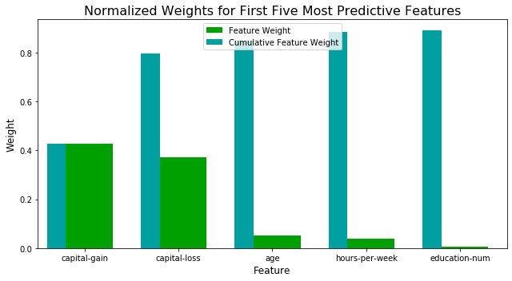

```python
# Extract the feature importances from our tuned model
importances = best_clf.feature_importances_

vs.feature_plot(importances, X_train, y_train) # Plot
```

From the graph above, we can see the two most influential features is `capital-gain` and `capital-loss`, accounting for around 80% of the importance of all the features in the data. Some of these were close to my initial thoughts, but overall the model seems to be taking influence from certain features more than others. These features are model specific, so if we used a different algorithm we could see different features having a larger influence. But for AdaBoost, these were the 5 most influential features our model found.

### Feature Selection (Training on a Subset)

```python
from sklearn.base import clone

# Reduce the feature space
X_train_reduced = X_train[X_train.columns.values[(np.argsort(importances)[::-1])[:5]]]
X_test_reduced = X_test[X_test.columns.values[(np.argsort(importances)[::-1])[:5]]]

clf = (clone(best_clf)).fit(X_train_reduced, y_train) # Train on the "best" model found from grid search earlier

reduced_predictions = clf.predict(X_test_reduced) # Make new predictions

# Report scores from the final model using both versions of data
print("Final Model trained on full data\n------")
print("Accuracy on testing data: {:.4f}".format(accuracy_score(y_test, best_predictions)))
print("F-score on testing data: {:.4f}".format(fbeta_score(y_test, best_predictions, beta = 0.5)))
print("\nFinal Model trained on reduced data\n------")
print("Accuracy on testing data: {:.4f}".format(accuracy_score(y_test, reduced_predictions)))
print("F-score on testing data: {:.4f}".format(fbeta_score(y_test, reduced_predictions, beta = 0.5)))
```

```
Final Model trained on full data
------
Accuracy on testing data: 0.8676
F-score on testing data: 0.7448

Final Model trained on reduced data
------
Accuracy on testing data: 0.8433
F-score on testing data: 0.7053
```

**Effects:** The model trained on only the top 5 features had worse performance in both accuracy and F-score, dropping around 2% in accuracy and 4% in F-score. And since our F-score is based more on precision, we want to stick with the optimized model to make sure we are asking for donations from the correct group of people.

If training time was a factor, and the dataset was much larger, I would consider using the reduced data. However, the training time for AdaBoost was only 2 seconds (from the graph of initial three models), so in this case I don't think using reduced data would be beneficial, especially because was lost 4% on the F-score from our best model.

If we had used a more computationally expensive models (like the SVM), then perhaps this would be worth considering.